# Assign ASVs with DADA2

Morrow Zhang

2026-04-21

# Set up the environment

```r
# Set Seed and Threads

set.seed(238428)
n_threads <- 50

# Timing of the script
start_time <- Sys.time()

# Load package
pacman::p_load(
  tidyverse, devtools, dada2, phyloseq,
  patchwork, DT, install = FALSE)
```

# Load Filtered Fastq Files

```r
# Place filtered seq files into a variable

filtered_fastqs_path <- "data/01_QualityTrimming/filtered_fastqs"

# Create forward vector

filtered_forward_reads <-
  list.files(filtered_fastqs_path,
             pattern = "R1_filtered.fastq.gz",
             full.names = TRUE)

# Create Reverse vector
filtered_reverse_reads <-
  list.files(filtered_fastqs_path,
             pattern = "R2_filtered.fastq.gz",
             full.names = TRUE)

# Create vector of sample names from the filenames

sample_names <- sapply(strsplit(basename(filtered_forward_reads), "_"), `[`, 1)
```

# Error Modelling

```r
# Forward Reads
error_forward_reads <-
  learnErrors(filtered_forward_reads,
              multithread = n_threads)
```

```
## 108595760 total bases in 387842 reads from 10 samples will be used for learning the error rates.
```

```r
# Forward Error Plot

forward_error_plot <-
  plotErrors(error_forward_reads, nominalQ = TRUE) +
  labs(title = "Forward Reads: Error Model")

# Reverse Reads

error_reverse_reads <-
  learnErrors(filtered_reverse_reads,
              multithread = n_threads)
```

```
## 104831760 total bases in 476508 reads from 13 samples will be used for learning the error rates.
```

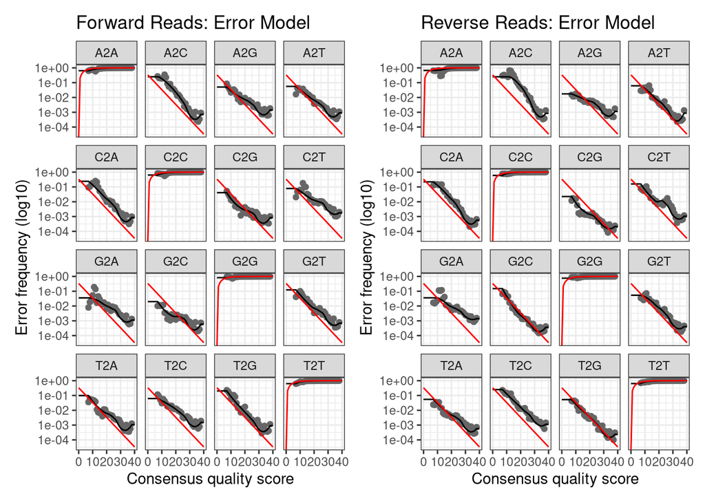

```r
# Reverse Error Plot
reverse_error_plot <-
  plotErrors(error_reverse_reads, nominalQ = TRUE) +
  labs(title = "Reverse Reads: Error Model")

# Put the plots together

forward_error_plot + reverse_error_plot
```

# Infer ASVs

```r
# Infer ASVs on forward sequences

dada_forward <-
  dada(
    filtered_forward_reads,
    err = error_forward_reads,
    multithread = n_threads
  )
```

```
## Sample 1 - 45902 reads in 10640 unique sequences.
## Sample 2 - 57003 reads in 14138 unique sequences.
## Sample 3 - 53620 reads in 12902 unique sequences.
## Sample 4 - 45710 reads in 12026 unique sequences.
## Sample 5 - 32397 reads in 10035 unique sequences.
## Sample 6 - 32217 reads in 8464 unique sequences.
## Sample 7 - 35068 reads in 9503 unique sequences.
## Sample 8 - 23997 reads in 6211 unique sequences.
## Sample 9 - 30860 reads in 7935 unique sequences.
## Sample 10 - 31068 reads in 9701 unique sequences.
## Sample 11 - 24360 reads in 6615 unique sequences.
## Sample 12 - 31923 reads in 8654 unique sequences.
## Sample 13 - 32383 reads in 9941 unique sequences.
## Sample 14 - 22145 reads in 5223 unique sequences.
## Sample 15 - 27968 reads in 5918 unique sequences.
## Sample 16 - 35893 reads in 10435 unique sequences.
## Sample 17 - 34930 reads in 10233 unique sequences.
## Sample 18 - 25648 reads in 5231 unique sequences.
## Sample 19 - 34248 reads in 10761 unique sequences.
## Sample 20 - 28275 reads in 9034 unique sequences.
## Sample 21 - 32785 reads in 9234 unique sequences.
## Sample 22 - 31349 reads in 8788 unique sequences.
## Sample 23 - 36121 reads in 9555 unique sequences.
## Sample 24 - 49096 reads in 12664 unique sequences.
## Sample 25 - 27647 reads in 6917 unique sequences.
## Sample 26 - 32551 reads in 10248 unique sequences.
## Sample 27 - 40928 reads in 12358 unique sequences.
## Sample 28 - 58277 reads in 16149 unique sequences.
## Sample 29 - 29076 reads in 9228 unique sequences.
## Sample 30 - 35942 reads in 11209 unique sequences.
## Sample 31 - 37425 reads in 12077 unique sequences.
## Sample 32 - 33243 reads in 11486 unique sequences.
## Sample 33 - 48067 reads in 16194 unique sequences.
## Sample 34 - 35364 reads in 10262 unique sequences.
## Sample 35 - 34798 reads in 11260 unique sequences.
## Sample 36 - 33197 reads in 10574 unique sequences.
## Sample 37 - 20740 reads in 6426 unique sequences.
## Sample 38 - 36822 reads in 11531 unique sequences.
## Sample 39 - 36865 reads in 12183 unique sequences.
## Sample 40 - 26415 reads in 8379 unique sequences.
## Sample 41 - 28896 reads in 9791 unique sequences.
## Sample 42 - 27306 reads in 9082 unique sequences.
## Sample 43 - 24508 reads in 8004 unique sequences.
## Sample 44 - 57478 reads in 14104 unique sequences.
## Sample 45 - 50805 reads in 12910 unique sequences.
## Sample 46 - 50138 reads in 14377 unique sequences.
## Sample 47 - 48369 reads in 12371 unique sequences.
## Sample 48 - 50369 reads in 13503 unique sequences.
## Sample 49 - 31167 reads in 8561 unique sequences.
```

```r
dada_reverse <-
  dada(
    filtered_reverse_reads,
    err = error_reverse_reads,
    multithread = n_threads
  )
```

```
## Sample 1 - 45902 reads in 10120 unique sequences.
## Sample 2 - 57003 reads in 12732 unique sequences.
## Sample 3 - 53620 reads in 11268 unique sequences.
## Sample 4 - 45710 reads in 10842 unique sequences.
## Sample 5 - 32397 reads in 8274 unique sequences.
## Sample 6 - 32217 reads in 8081 unique sequences.
## Sample 7 - 35068 reads in 9270 unique sequences.
## Sample 8 - 23997 reads in 5476 unique sequences.
## Sample 9 - 30860 reads in 8348 unique sequences.
## Sample 10 - 31068 reads in 8865 unique sequences.
## Sample 11 - 24360 reads in 6675 unique sequences.
## Sample 12 - 31923 reads in 8060 unique sequences.
## Sample 13 - 32383 reads in 9830 unique sequences.
## Sample 14 - 22145 reads in 5340 unique sequences.
## Sample 15 - 27968 reads in 5897 unique sequences.
## Sample 16 - 35893 reads in 8618 unique sequences.
## Sample 17 - 34930 reads in 8853 unique sequences.
## Sample 18 - 25648 reads in 5351 unique sequences.
## Sample 19 - 34248 reads in 9044 unique sequences.
## Sample 20 - 28275 reads in 8199 unique sequences.
## Sample 21 - 32785 reads in 8143 unique sequences.
## Sample 22 - 31349 reads in 8062 unique sequences.
## Sample 23 - 36121 reads in 8996 unique sequences.
## Sample 24 - 49096 reads in 10834 unique sequences.
## Sample 25 - 27647 reads in 10537 unique sequences.
## Sample 26 - 32551 reads in 13147 unique sequences.
## Sample 27 - 40928 reads in 12995 unique sequences.
## Sample 28 - 58277 reads in 14926 unique sequences.
## Sample 29 - 29076 reads in 12559 unique sequences.
## Sample 30 - 35942 reads in 10860 unique sequences.
## Sample 31 - 37425 reads in 11895 unique sequences.
## Sample 32 - 33243 reads in 10480 unique sequences.
## Sample 33 - 48067 reads in 12416 unique sequences.
## Sample 34 - 35364 reads in 9357 unique sequences.
## Sample 35 - 34798 reads in 9036 unique sequences.
## Sample 36 - 33197 reads in 9214 unique sequences.
## Sample 37 - 20740 reads in 5393 unique sequences.
## Sample 38 - 36822 reads in 11601 unique sequences.
## Sample 39 - 36865 reads in 12305 unique sequences.
## Sample 40 - 26415 reads in 10730 unique sequences.
## Sample 41 - 28896 reads in 13111 unique sequences.
## Sample 42 - 27306 reads in 12176 unique sequences.
## Sample 43 - 24508 reads in 10953 unique sequences.
## Sample 44 - 57478 reads in 13697 unique sequences.
## Sample 45 - 50805 reads in 12335 unique sequences.
## Sample 46 - 50138 reads in 13878 unique sequences.
## Sample 47 - 48369 reads in 11195 unique sequences.
## Sample 48 - 50369 reads in 12456 unique sequences.
## Sample 49 - 31167 reads in 8351 unique sequences.
```

# Merge Forward and Reverse ASVs

```r
merged_ASVs <-
  mergePairs(
    dada_forward, filtered_forward_reads,
    dada_reverse, filtered_reverse_reads,
    verbose = TRUE
  )
```

```
## 44593 paired-reads (in 301 unique pairings) successfully merged out of 45175 (in 486 pairings) input.
```

```
## 54448 paired-reads (in 496 unique pairings) successfully merged out of 55395 (in 803 pairings) input.
```

```
## 51245 paired-reads (in 491 unique pairings) successfully merged out of 52353 (in 850 pairings) input.
```

```
## 43530 paired-reads (in 510 unique pairings) successfully merged out of 44179 (in 761 pairings) input.
```

```
## 30300 paired-reads (in 395 unique pairings) successfully merged out of 31061 (in 669 pairings) input.
```

```
## 30462 paired-reads (in 284 unique pairings) successfully merged out of 31005 (in 501 pairings) input.
```

```
## 33287 paired-reads (in 370 unique pairings) successfully merged out of 34094 (in 646 pairings) input.
```

```
## 22662 paired-reads (in 255 unique pairings) successfully merged out of 23328 (in 442 pairings) input.
```

```
## 29266 paired-reads (in 320 unique pairings) successfully merged out of 29862 (in 604 pairings) input.
```

```
## 28806 paired-reads (in 370 unique pairings) successfully merged out of 29559 (in 710 pairings) input.
```

```
## 22911 paired-reads (in 269 unique pairings) successfully merged out of 23323 (in 420 pairings) input.
```

```
## 30316 paired-reads (in 318 unique pairings) successfully merged out of 30840 (in 488 pairings) input.
```

```
## 29554 paired-reads (in 345 unique pairings) successfully merged out of 30820 (in 701 pairings) input.
```

```
## 21102 paired-reads (in 161 unique pairings) successfully merged out of 21713 (in 292 pairings) input.
```

```
## 27046 paired-reads (in 212 unique pairings) successfully merged out of 27336 (in 308 pairings) input.
```

```
## 33826 paired-reads (in 423 unique pairings) successfully merged out of 34396 (in 652 pairings) input.
```

```
## 32266 paired-reads (in 472 unique pairings) successfully merged out of 33274 (in 787 pairings) input.
```

```
## 24965 paired-reads (in 202 unique pairings) successfully merged out of 25189 (in 281 pairings) input.
```

```
## 31538 paired-reads (in 395 unique pairings) successfully merged out of 32464 (in 729 pairings) input.
```

```
## 25900 paired-reads (in 381 unique pairings) successfully merged out of 26793 (in 773 pairings) input.
```

```
## 30759 paired-reads (in 360 unique pairings) successfully merged out of 31431 (in 605 pairings) input.
```

```
## 29341 paired-reads (in 340 unique pairings) successfully merged out of 30008 (in 605 pairings) input.
```

```
## 34193 paired-reads (in 397 unique pairings) successfully merged out of 34965 (in 653 pairings) input.
```

```
## 46514 paired-reads (in 478 unique pairings) successfully merged out of 47697 (in 790 pairings) input.
```

```
## 26314 paired-reads (in 185 unique pairings) successfully merged out of 26898 (in 318 pairings) input.
```

```
## 29865 paired-reads (in 293 unique pairings) successfully merged out of 31207 (in 640 pairings) input.
```

```
## 37809 paired-reads (in 484 unique pairings) successfully merged out of 39014 (in 1059 pairings) input.
```

```
## 54758 paired-reads (in 679 unique pairings) successfully merged out of 55770 (in 1086 pairings) input.
```

```
## 26896 paired-reads (in 300 unique pairings) successfully merged out of 27390 (in 500 pairings) input.
```

```
## 33139 paired-reads (in 391 unique pairings) successfully merged out of 34060 (in 791 pairings) input.
```

```
## 33932 paired-reads (in 495 unique pairings) successfully merged out of 35196 (in 915 pairings) input.
```

```
## 29929 paired-reads (in 446 unique pairings) successfully merged out of 31112 (in 879 pairings) input.
```

```
## 44671 paired-reads (in 551 unique pairings) successfully merged out of 45739 (in 968 pairings) input.
```

```
## 32996 paired-reads (in 328 unique pairings) successfully merged out of 34160 (in 691 pairings) input.
```

```
## 32028 paired-reads (in 338 unique pairings) successfully merged out of 33081 (in 682 pairings) input.
```

```
## 30530 paired-reads (in 356 unique pairings) successfully merged out of 31549 (in 664 pairings) input.
```

```
## 19214 paired-reads (in 257 unique pairings) successfully merged out of 19845 (in 458 pairings) input.
```

```
## 34019 paired-reads (in 469 unique pairings) successfully merged out of 34961 (in 919 pairings) input.
```

```
## 33578 paired-reads (in 445 unique pairings) successfully merged out of 34460 (in 904 pairings) input.
```

```
## 24371 paired-reads (in 260 unique pairings) successfully merged out of 24905 (in 463 pairings) input.
```

```
## 25482 paired-reads (in 271 unique pairings) successfully merged out of 26987 (in 609 pairings) input.
```

```
## 24940 paired-reads (in 258 unique pairings) successfully merged out of 25643 (in 525 pairings) input.
```

```
## 22605 paired-reads (in 244 unique pairings) successfully merged out of 23001 (in 422 pairings) input.
```

```
## 55053 paired-reads (in 502 unique pairings) successfully merged out of 55777 (in 807 pairings) input.
```

```
## 48447 paired-reads (in 522 unique pairings) successfully merged out of 49345 (in 871 pairings) input.
```

```
## 46190 paired-reads (in 582 unique pairings) successfully merged out of 47798 (in 1190 pairings) input.
```

```
## 46051 paired-reads (in 520 unique pairings) successfully merged out of 46821 (in 815 pairings) input.
```

```
## 47355 paired-reads (in 507 unique pairings) successfully merged out of 48580 (in 1000 pairings) input.
```

```
## 29389 paired-reads (in 343 unique pairings) successfully merged out of 30104 (in 666 pairings) input.
```

```r
typeof(merged_ASVs)
```

```
## [1] "list"
```

```r
length(merged_ASVs)
```

```
## [1] 49
```

# Create Raw ASV count table

```r
# Raw ASV
raw_ASV_table <- makeSequenceTable(merged_ASVs)

# Check

dim(raw_ASV_table)
```

```
## [1]    49 10725
```

```r
typeof(raw_ASV_table)
```

```
## [1] "integer"
```

```r
class(raw_ASV_table)
```

```
## [1] "matrix" "array"
```

# Assess ASV Quality

## ASV Length Stats

```r
maxLength_ASV <- max(nchar(getSequences(raw_ASV_table)))
minLength_ASV <- min(nchar(getSequences(raw_ASV_table)))
meanLength_ASV <- mean(nchar(getSequences(raw_ASV_table)))
medianLength_ASV <- median(nchar(getSequences(raw_ASV_table)))
table(nchar(getSequences(raw_ASV_table)))
```

```
##
##  280  287  300  326  331  336  344  356  361  372  378  383  384  385  386  390
##   52    2    1    1    1    1    3    1    1    1    1    1    1    2    2    1
##  392  396  398  399  400  401  402  403  404  405  406  407  408  409  410  411
##    1    1    1    3  670 2006 1850  399  349  281  135  270  289  163   70   40
##  412  413  415  416  417  418  419  420  421  422  423  424  425  426  427  428
##   11    4    3   23   54   87   88   52  249 1354  407   13   10  262 1155  222
##  429  430  436  437  439  440  441  442  443  444  445  446  452  454  468  469
##   25    1    3    1   15   26   20    1    2   13   18    1    1    1    1    1
##  485
##    1
```

### INTERPRETATION 1

1. The sequencing strategy used for the dataset is paired-end IIIumina sequencing (2*250 bp reads) tagrteing the 16s rRNA V3-V4 region.
2. The total starting amplicon length including primers is expected to be around 460 bp.
3. After removing primer sequences (17 bp forward and 21 bp reverse), the expected ASV length is approximately 422 bp.
4. Following the filterAndTrim() step, forward reads were truncated to 280 bp and reverse reads to 220 bp to remove low-quality bases identified in the FastQC and MultiQC reports.
5. Based on these trimmed read lengths and the expected insert length of ~422 bp, the expected overlap between forward and reverse reads is approximately 78 bp, corresponding to an expected percent overlap of approximately 18%

## ASV Length Plot

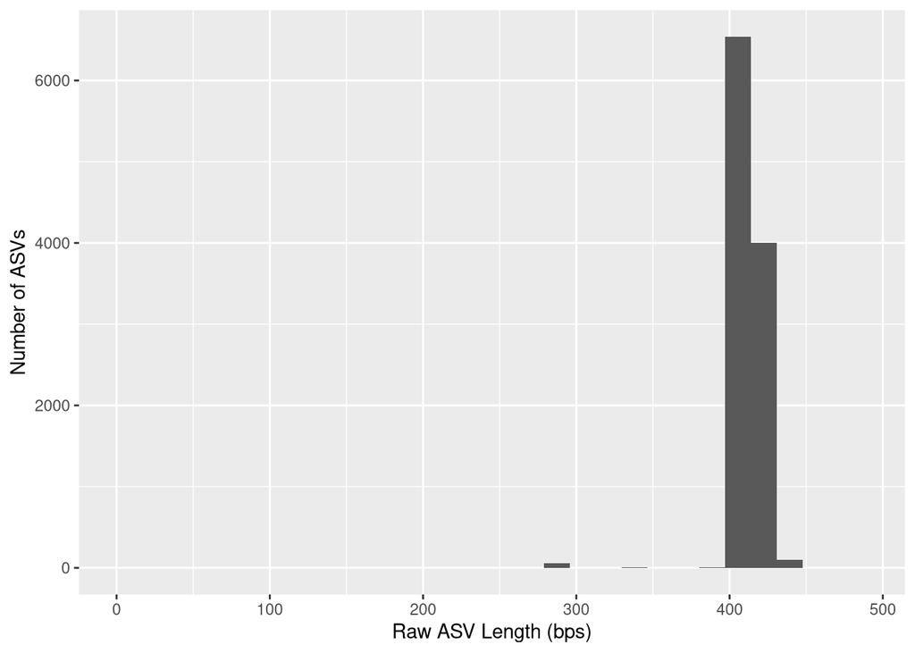

```r
# Inspect the distribution of sequence lengths of all ASVs in data set
# After TRIM
plot_ASVLength_raw <-
  data.frame(Seq_Length = nchar(getSequences(raw_ASV_table))) %>%
  ggplot(aes(x = Seq_Length)) +
  geom_histogram() +
  scale_x_continuous(limits = c(0, maxLength_ASV + 5)) +
  labs(y = "Number of ASVs", x = "Raw ASV Length (bps)")

# Show plot

plot_ASVLength_raw
```

### INTERPRETATION 2

The ASV length data generally matches the hypotheses proposed in INTERPRETATION #1. The histogram and length table show that most ASVs cluster between approximately 400 and 430 base pairs, with a strong peak centered around 410 bp. This observed range is consistent with the expected length of the 16S rRNA V3–V4 amplicon after primer removal, which was hypothesized to be approximately 422 bp.

### INTERPRETATION 3

Taking into account INTERPRETATIONS #1 and #2, with Mar’s suggestion, the ASV sequences should be trimmed to a range of length of approximately 400 to 404, 421 to 423, and 426 and 428 to avoid losing too much sequences. The ASV length table and histogram show that most ASVs cluster tightly around 400 to 428 bps. Although some shorter and longer sequences are present, these likely represent sequencing artifacts or non-target sequences. Therefore, trimming to length around 400 to 404, 421 to 423, and 426 and 428 will standardize the dataset and remove irregular sequences.

# Trim ASV lengths

```r
raw_ASV_table_trimmed <-
  raw_ASV_table[, nchar(colnames(raw_ASV_table)) %in% c(400:404, 421:423, 426:428)]     # == 403]
table(nchar(getSequences(raw_ASV_table_trimmed)))
```

```
##
##  400  401  402  403  404  421  422  423  426  427  428
##  670 2006 1850  399  349  249 1354  407  262 1155  222
```

```r
percRetained_Trimmed <- sum(raw_ASV_table_trimmed) / sum(raw_ASV_table)
percRetained_Trimmed
```

```
## [1] 0.8962211
```

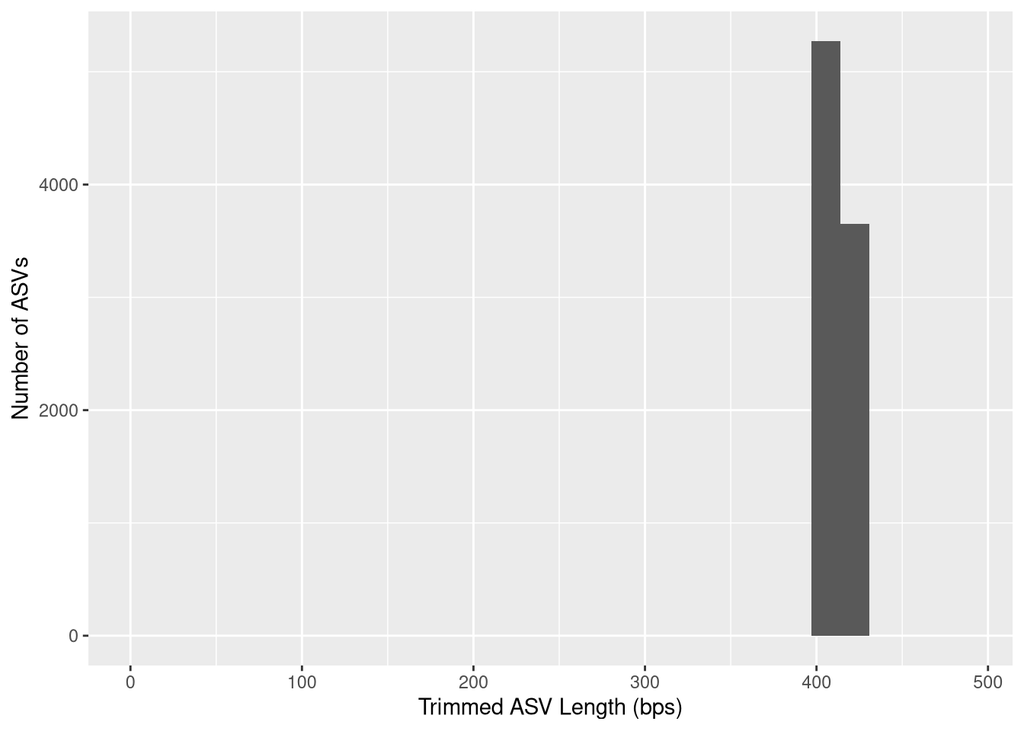

```r
plot_ASVLength_trimmed <-
  data.frame(Seq_Length = nchar(getSequences(raw_ASV_table_trimmed))) %>%
  ggplot(aes(x = Seq_Length)) +
  geom_histogram() +
  scale_x_continuous(limits = c(0, maxLength_ASV + 5)) +
  labs(y = "Number of ASVs", x = "Trimmed ASV Length (bps)")

# Show Plot

plot_ASVLength_trimmed
```

# Remove Chimeras

```r
# Remove the chimeras in the raw ASV table

noChimeras_ASV_table <-
  removeBimeraDenovo(
    raw_ASV_table_trimmed,
    method = "consensus",
    multithread = n_threads,
    verbose = TRUE
  )
```

```
## Identified 6037 bimeras out of 8923 input sequences.
```

```r
# Check for dimensions

dim(noChimeras_ASV_table)
```

```
## [1]   49 2886
```

```r
# what proportion is left of the sequences?
# Chimera removal compared to trimming
percRetained_chimerasTrimmed <- sum(noChimeras_ASV_table) / sum(raw_ASV_table_trimmed)
percRetained_chimerasTrimmed
```

```
## [1] 0.9533044
```

```r
# Chimera removal compared to raw
percRetained_chimerasRaw <- sum(noChimeras_ASV_table) / sum(raw_ASV_table)
percRetained_chimerasRaw
```

```
## [1] 0.8543715
```

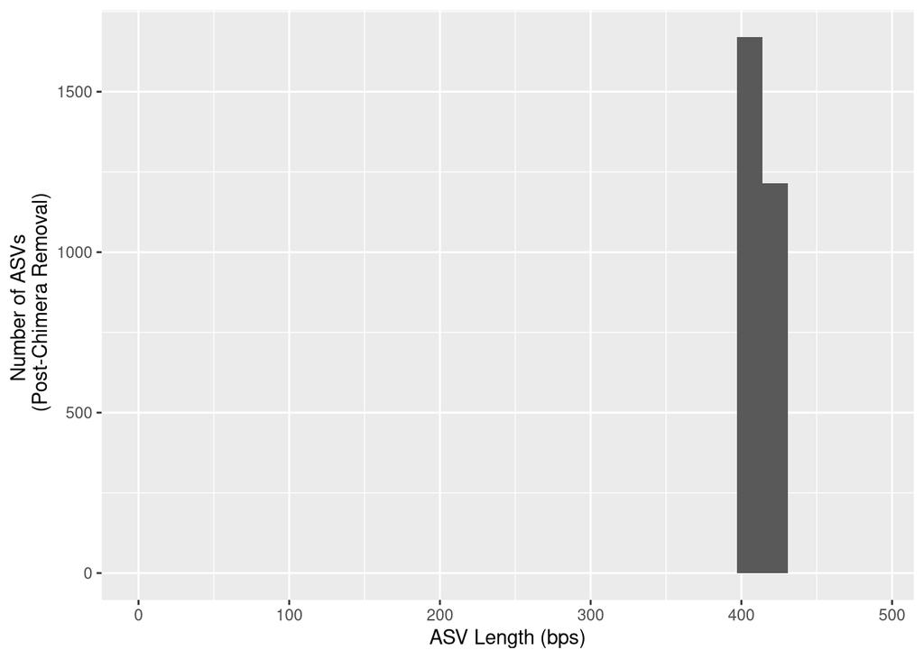

```r
# Plot it
plot_ASVLength_NoChimeras <-
  data.frame(Seq_Length_NoChim = nchar(getSequences(noChimeras_ASV_table))) %>%
  ggplot(aes(x = Seq_Length_NoChim)) +
  geom_histogram() +
  scale_x_continuous(limits = c(0, maxLength_ASV + 5)) +
  labs(y = "Number of ASVs \n (Post-Chimera Removal)",
       x = "ASV Length (bps)")

# Show the Plot
plot_ASVLength_NoChimeraS <- plot_ASVLength_NoChimeras
plot_ASVLength_NoChimeras
```

### INTERPRETATION 4

After chimera removal, 2886 ASVs were retained across 49 samples. Approximately 95.33% of the trimmed sequences remained after chimera removal, and about 85.44% of the original raw sequences were retained overall.

# Plot ASV Lengths

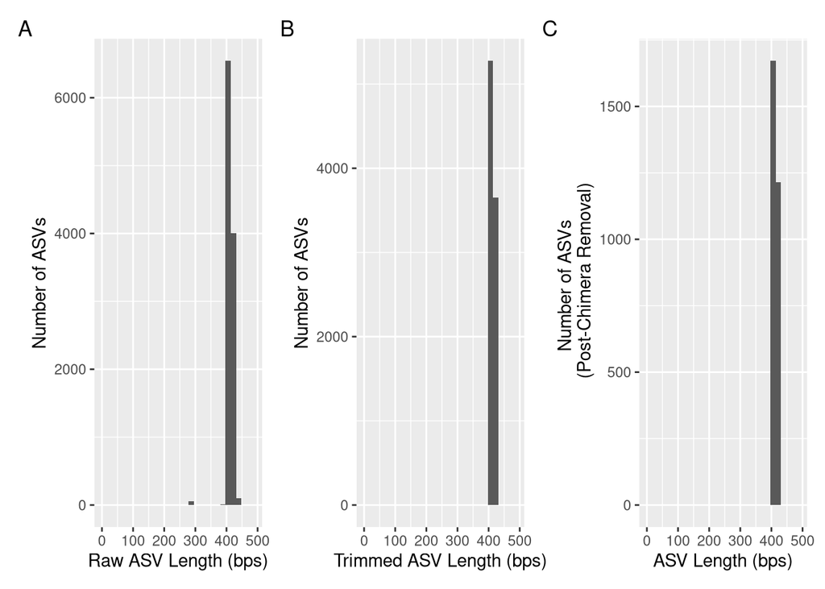

```r
plot_ASVLength_raw + plot_ASVLength_trimmed + plot_ASVLength_NoChimeras +
  plot_annotation(tag_levels = 'A')
```

# Track the read counts

```r
# function to identify number seqs

getN <- function(x) sum(getUniques(x))

# Make the table to track the seqs

track <- cbind(
  sapply(dada_forward, getN),
  sapply(dada_reverse, getN),
  sapply(merged_ASVs, getN),
  rowSums(noChimeras_ASV_table)
)

head(track)
```

```
##                                   [,1]  [,2]  [,3]  [,4]
## SRR35320041_R1_filtered.fastq.gz 45417 45617 44593 38755
## SRR35320051_R1_filtered.fastq.gz 55882 56432 54448 45635
## SRR35320062_R1_filtered.fastq.gz 52694 53211 51245 45397
## SRR35320071_R1_filtered.fastq.gz 44614 45193 43530 37841
## SRR35320072_R1_filtered.fastq.gz 31343 32013 30300 27531
## SRR35320073_R1_filtered.fastq.gz 31348 31831 30462 26875
```

```r
# Update column names to be more informative

colnames(track) <- c("denoisedF", "denoisedR", "merged", "nochim")
rownames(track) <- row.names(noChimeras_ASV_table)

# Create a dataframe to track the reads through DADA2 pipeline

track_counts_df <-
  track %>%
  as.data.frame() %>%
  rownames_to_column(var = "sample_names")

# Intuition check

stopifnot(track_counts_df$sample_names == row.names(noChimeras_ASV_table))


# add a new column with number of ASVs
track_counts_df <-
  track_counts_df %>%
  mutate(num_ASVs = rowSums(noChimeras_ASV_table > 1))

# Visualize it in table format
DT::datatable(track_counts_df)
```

|  | sample_names | denoisedF | denoisedR | merged | nochim | num_ASVs |
| --- | --- | --- | --- | --- | --- | --- |
| 1 | SRR35320041_R1_filtered.fastq.gz | 45417 | 45617 | 44593 | 38755 | 129 |
| 2 | SRR35320051_R1_filtered.fastq.gz | 55882 | 56432 | 54448 | 45635 | 173 |
| 3 | SRR35320062_R1_filtered.fastq.gz | 52694 | 53211 | 51245 | 45397 | 142 |
| 4 | SRR35320071_R1_filtered.fastq.gz | 44614 | 45193 | 43530 | 37841 | 185 |
| 5 | SRR35320072_R1_filtered.fastq.gz | 31343 | 32013 | 30300 | 27531 | 197 |
| 6 | SRR35320073_R1_filtered.fastq.gz | 31348 | 31831 | 30462 | 26875 | 132 |
| 7 | SRR35320074_R1_filtered.fastq.gz | 34388 | 34712 | 33287 | 27623 | 136 |
| 8 | SRR35320075_R1_filtered.fastq.gz | 23558 | 23711 | 22662 | 17176 | 105 |
| 9 | SRR35320076_R1_filtered.fastq.gz | 30151 | 30495 | 29266 | 26366 | 135 |
| 10 | SRR35320077_R1_filtered.fastq.gz | 29926 | 30600 | 28806 | 24450 | 184 |

[output cut: 39 more lines]

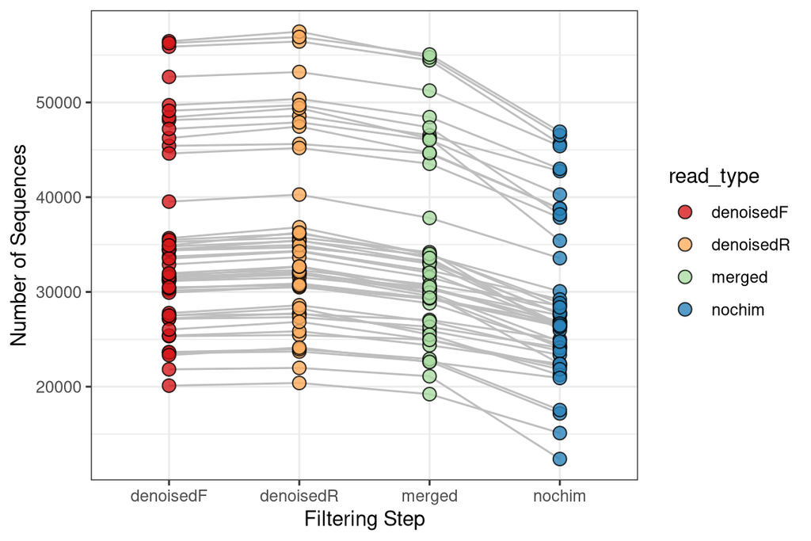

```r
# Plot it
track_counts_df %>%
  pivot_longer(denoisedF:nochim, names_to = "read_type", values_to = "num_reads") %>%
  mutate(read_type = fct_relevel(read_type, "denoisedF", "denoisedR", "merged", "nochim")) %>%
  ggplot(aes(x = read_type, y = num_reads, fill = read_type)) +
  geom_line(aes(group = sample_names), color = "grey") +
  geom_point(shape = 21, size = 3, alpha = 0.8) +
  scale_fill_brewer(palette = "Spectral") +
  labs(x = "Filtering Step", y = "Number of Sequences") +
  theme_bw()
```

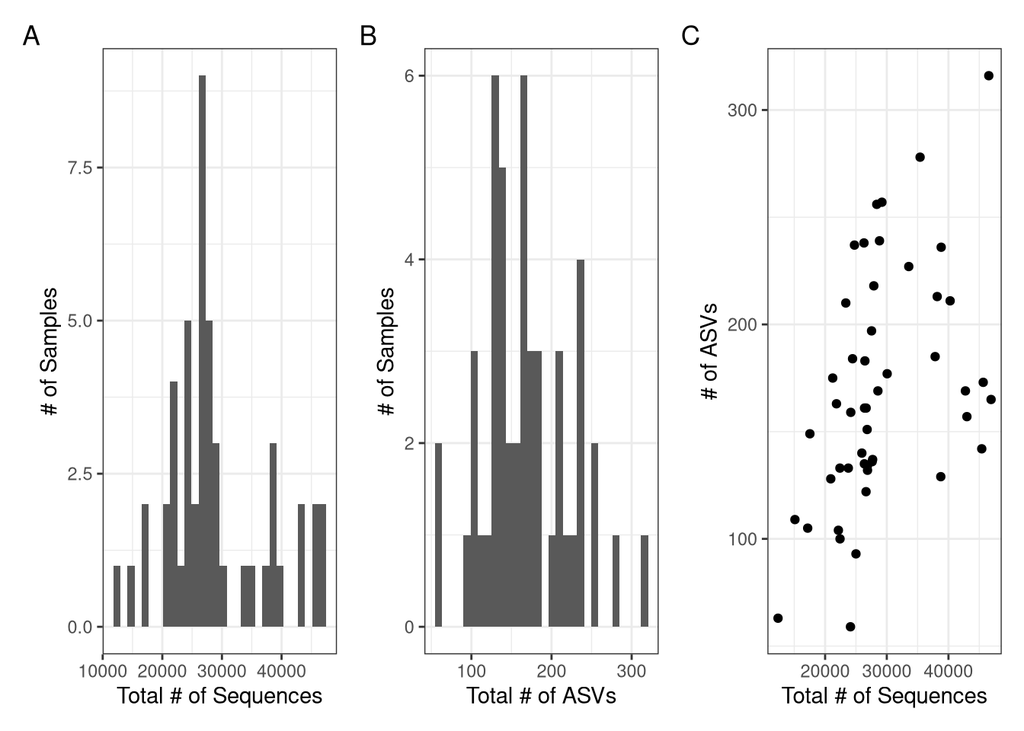

```r
plot_ReadDepth <-
  track_counts_df %>%
  ggplot(aes(x = nochim)) +
  geom_histogram() +
  labs(x = "Total # of Sequences", y = "# of Samples") +
  theme_bw()

# What is the ASV richness per sample?

plot_ASVRichness <-
  track_counts_df %>%
  ggplot(aes(x = num_ASVs)) +
  geom_histogram() +
  labs(x = "Total # of ASVs", y = "# of Samples") +
  theme_bw()

# look at the relationship of ASVs and Sequencing depth

plot_ReadDepth_ASVRichness <-
  track_counts_df %>%
  ggplot(aes(x = nochim, y = num_ASVs)) +
  geom_point() +
  labs(x = "Total # of Sequences", y = "# of ASVs") +
  theme_bw()

# Show the plots together

plot_ReadDepth + plot_ASVRichness + plot_ReadDepth_ASVRichness +
  plot_annotation(tag_levels = "A")
```

### INTERPRETATION 5

Panel A shows variation in sequencing depth across samples. Most samples contain approximately 20,000 to 30,000 total sequences, although a few samples have lower or higher sequencing depth.

Panel B shows that most samples contain roughly 100 to 220 ASVs, with some samples having fewer and some exceeding 250 ASVs.

Panel C shows a positive relationship between total sequencing depth and total ASV richness. In general, samples with higher sequencing depth tend to have more detected ASVs, indicating that sequencing depth influences the number of ASVs observed.

Overall, these plots indicate that sequencing depth varies across samples and likely affects observed ASV richness. This suggests that sequencing depth should be considered in downstream diversity analyses.

# Assign Taxonomy

```r
# Here I am trying to find out which one of the sample is not used.
raw_fastqs_path <- "data/00_raw_gzipped_fastqs"

forward_reads <- list.files(raw_fastqs_path, pattern = "_1.fastq.gz$", full.names = TRUE)

filtered_fastqs_path <- "data/01_QualityTrimming/filtered_fastqs"
expected <- readLines("data/SRR_Acc_List (3).txt")
actual <- gsub("_1.fastq.gz", "", basename(forward_reads))
setdiff(expected, actual)
```

```
## [1] "SRR35320083"
```

```r
# Here I am extracting metadat related information

metadata <- read.csv("data/SraRunTable (11).csv")
metadata$AttemptStatus <- ifelse(
  grepl("non attempters", metadata$source_material_id),
  "Non-attempter",
  "Attempter"
)
```

```r
# Assign up to genus level

taxa_train <- assignTaxonomy(
  noChimeras_ASV_table,
  refFasta = "/workdir/in_class_data/taxonomy/silva_nr99_v138.2_toGenus_trainset.fa.gz",
  multithread = n_threads
)

# Add the genus/species information

taxa_addSpecies <- addSpecies(
  taxa_train,
  refFasta = "/workdir/in_class_data/taxonomy/silva_v138.2_assignSpecies.fa.gz"
)

# take a look
dim(taxa_addSpecies)
```

```
## [1] 2886    7
```

```r
# remove the ASV sequence rownames for display only

taxa_print <- taxa_addSpecies
rownames(taxa_print) <- NULL
head(taxa_print)
```

```
##      Kingdom    Phylum         Class
## [1,] "Bacteria" "Bacillota"    "Clostridia"
## [2,] "Bacteria" "Bacillota"    "Clostridia"
## [3,] "Bacteria" "Bacteroidota" "Bacteroidia"
## [4,] "Bacteria" "Bacillota"    "Clostridia"
## [5,] "Bacteria" "Bacillota"    "Clostridia"
## [6,] "Bacteria" "Bacillota"    "Clostridia"
##      Order                                 Family           Genus
## [1,] "Peptostreptococcales-Tissierellales" "Family XI"      "Finegoldia"
## [2,] "Peptostreptococcales-Tissierellales" "Family XI"      "Peptoniphilus"
## [3,] "Bacteroidales"                       "Prevotellaceae" "Prevotella"
## [4,] "Peptostreptococcales-Tissierellales" "Family XI"      "Anaerococcus"
## [5,] "Peptostreptococcales-Tissierellales" "Family XI"      "Fenollaria"
## [6,] "Peptostreptococcales-Tissierellales" "Family XI"      "Ezakiella"
##      Species
## [1,] "magna"
## [2,] NA
## [3,] "corporis"
## [4,] "vaginalis"
## [5,] NA
## [6,] NA
```

# Export the Data

```r
# See the current format of the ASV table

head(rownames(noChimeras_ASV_table))
```

```
## [1] "SRR35320041_R1_filtered.fastq.gz" "SRR35320051_R1_filtered.fastq.gz"
## [3] "SRR35320062_R1_filtered.fastq.gz" "SRR35320071_R1_filtered.fastq.gz"
## [5] "SRR35320072_R1_filtered.fastq.gz" "SRR35320073_R1_filtered.fastq.gz"
```

```r
head(colnames(noChimeras_ASV_table))
```

```
## [1] "TGGGGAATATTGCACAATGGGGGAAACCCTGATGCAGCGACGCCGCGTGAACGAAGAAGG…"
## [2] "TGGGGAATATTGCACAATGGAGGGAACTCTGATGCAGCGACGCCGCGTGAACGAAGAAGG…"
## [3] "TGAGGAATATTGGTCAATGGGCGCTAGCCTGAACCAGCCAAGTAGCGTGCAGGATGACGG…"
## [4] "TGGGGAATTTTGCACAATGGGGGAAACCCTGATGCAGCGACGCCGCGTGATTTAGAAGGC…"
## [5] "TGGGGAATATTGCACAATGGGGGAAACCCTGATGCAGCGACGCCGCGTGAGCGATGAAGG…"
## [6] "TGGGGAATATTGCACAATGGAGGGAACTCTGATGCAGCGACGCCGCGTGAGTGATGAAGG…"
```

```r
# transpose the matrix
final_ASV_table_withSeqs <- t(noChimeras_ASV_table)

# Check
head(rownames(final_ASV_table_withSeqs))
```

```
## [1] "TGGGGAATATTGCACAATGGGGGAAACCCTGATGCAGCGACGCCGCGTGAACGAAGAAGG…"
## [2] "TGGGGAATATTGCACAATGGAGGGAACTCTGATGCAGCGACGCCGCGTGAACGAAGAAGG…"
## [3] "TGAGGAATATTGGTCAATGGGCGCTAGCCTGAACCAGCCAAGTAGCGTGCAGGATGACGG…"
## [4] "TGGGGAATTTTGCACAATGGGGGAAACCCTGATGCAGCGACGCCGCGTGATTTAGAAGGC…"
## [5] "TGGGGAATATTGCACAATGGGGGAAACCCTGATGCAGCGACGCCGCGTGAGCGATGAAGG…"
## [6] "TGGGGAATATTGCACAATGGAGGGAACTCTGATGCAGCGACGCCGCGTGAGTGATGAAGG…"
```

```r
head(colnames(final_ASV_table_withSeqs))
```

```
## [1] "SRR35320041_R1_filtered.fastq.gz" "SRR35320051_R1_filtered.fastq.gz"
## [3] "SRR35320062_R1_filtered.fastq.gz" "SRR35320071_R1_filtered.fastq.gz"
## [5] "SRR35320072_R1_filtered.fastq.gz" "SRR35320073_R1_filtered.fastq.gz"
```

# Names in ASV tables

```r
head(sample_names)
```

```
## [1] "SRR35320041" "SRR35320051" "SRR35320062" "SRR35320071" "SRR35320072"
## [6] "SRR35320073"
```

```r
# check with the actual column names

head(colnames(final_ASV_table_withSeqs))
```

```
## [1] "SRR35320041_R1_filtered.fastq.gz" "SRR35320051_R1_filtered.fastq.gz"
## [3] "SRR35320062_R1_filtered.fastq.gz" "SRR35320071_R1_filtered.fastq.gz"
## [5] "SRR35320072_R1_filtered.fastq.gz" "SRR35320073_R1_filtered.fastq.gz"
```

```r
# apply sample name script to check as well

head(sapply(strsplit(colnames(final_ASV_table_withSeqs), "_"), `[`, 1))
```

```
## [1] "SRR35320041" "SRR35320051" "SRR35320062" "SRR35320071" "SRR35320072"
## [6] "SRR35320073"
```

```r
# Make sure the sample name match the file names in the matrix

stopifnot(sapply(strsplit(colnames(final_ASV_table_withSeqs), "_"), `[`,1) == sample_names)

# renaming
colnames(final_ASV_table_withSeqs) <- sample_names
head(colnames(final_ASV_table_withSeqs))
```

```
## [1] "SRR35320041" "SRR35320051" "SRR35320062" "SRR35320071" "SRR35320072"
## [6] "SRR35320073"
```

```r
# rename ASV

ASV_seqs <- rownames(final_ASV_table_withSeqs)
ASV_seqs[1:5]
```

```
## [1] "TGGGGAATATTGCACAATGGGGGAAACCCTGATGCAGCGACGCCGCGTGAACGAAGAAGG…"
## [2] "TGGGGAATATTGCACAATGGAGGGAACTCTGATGCAGCGACGCCGCGTGAACGAAGAAGG…"
## [3] "TGAGGAATATTGGTCAATGGGCGCTAGCCTGAACCAGCCAAGTAGCGTGCAGGATGACGG…"
## [4] "TGGGGAATTTTGCACAATGGGGGAAACCCTGATGCAGCGACGCCGCGTGATTTAGAAGGC…"
## [5] "TGGGGAATATTGCACAATGGGGGAAACCCTGATGCAGCGACGCCGCGTGAGCGATGAAGG…"
```

```r
# number of ASV
num_ASVs <- dim(final_ASV_table_withSeqs)[1] # select the number of rows
num_ASVs
```

```
## [1] 2886
```

```r
# make an empty vector the length of the number of ASVs

ASV_headers <- vector(num_ASVs, mode = "character")

ASV_headers[1:5]
```

```
## [1] "" "" "" "" ""
```

```r
length(ASV_headers)
```

```
## [1] 2886
```

```r
# Create a vector with ASV numbers

for (i in 1:num_ASVs) {
  ASV_number <- sprintf("%04d", i)
  ASV_headers[i] <- paste(">ASV", ASV_number, sep = "_")
}

ASV_headers[1:5]
```

```
## [1] ">ASV_0001" ">ASV_0002" ">ASV_0003" ">ASV_0004" ">ASV_0005"
```

```r
final_ASV_table <- final_ASV_table_withSeqs

glimpse(final_ASV_table)
```

```
##  int [1:2886, 1:49] 2389 2874 5157 3311 125 18 0 0 2203 142 ...
##  - attr(*, "dimnames")=List of 2
##   ..$ : chr [1:2886] "TGGGGAATATTGCACAATGGGGGAAACCCTGATGCAGCGACGCCGCGTGAACGAAGAAGGTATTCGTATCGTAAAGTTCTGTCCTATGGGAAGATAATGACAGTACCATAG"| __truncated__ "TGGGGAATATTGCACAATGGAGGGAACTCTGATGCAGCGACGCCGCGTGAACGAAGAAGGCTTTCGAGTCGTAAAGTTCTTTTATATGGGAAGATAATGACGGTACCATAA"| __truncated__ "TGAGGAATATTGGTCAA…
##   ..$ : chr [1:49] "SRR35320041" "SRR35320051" "SRR35320062" "SRR35320071" ...
```

```r
row.names(final_ASV_table) <- sub(">", "", ASV_headers)

# Check
final_ASV_table[1:5, 1:5]
```

```
##          SRR35320041 SRR35320051 SRR35320062 SRR35320071 SRR35320072
## ASV_0001        2389        4973       12303        5214        4380
## ASV_0002        2874        2425        1127        2670        1699
## ASV_0003        5157        7284        1526        1070          71
## ASV_0004        3311        2111         153        1012         610
## ASV_0005         125         514         442        3010        1101
```

## Write the ASV Tables

```r
# Write count table with ASV sequence names

write.table(final_ASV_table_withSeqs,
            file = "data/ASV_table_withSeqNames.tsv",
            sep = "\t", quote = FALSE, col.names = NA)

# Write count table with ASV numbered names

write.table(final_ASV_table,
            file = "data/ASV_table.tsv",
            sep = "\t", quote = FALSE, col.names = NA)
```

# Write the ASV Fasta File

```r
head(ASV_headers, n = 2)
```

```
## [1] ">ASV_0001" ">ASV_0002"
```

```r
head(ASV_seqs, n = 2)
```

```
## [1] "TGGGGAATATTGCACAATGGGGGAAACCCTGATGCAGCGACGCCGCGTGAACGAAGAAGG…"
## [2] "TGGGGAATATTGCACAATGGAGGGAACTCTGATGCAGCGACGCCGCGTGAACGAAGAAGG…"
```

```r
ASV_fasta <- c(rbind(ASV_headers, ASV_seqs))

head(ASV_fasta, n = 4)
```

```
## [1] ">ASV_0001"
## [2] "TGGGGAATATTGCACAATGGGGGAAACCCTGATGCAGCGACGCCGCGTGAACGAAGAAGG…"
## [3] ">ASV_0002"
## [4] "TGGGGAATATTGCACAATGGAGGGAACTCTGATGCAGCGACGCCGCGTGAACGAAGAAGG…"
```

```r
writeLines(ASV_fasta,
           con = "data/ASVs.fasta")
```

#Taxonomy Table

```r
dim(taxa_addSpecies)
```

```
## [1] 2886    7
```

```r
colnames(taxa_addSpecies)
```

```
## [1] "Kingdom" "Phylum"  "Class"   "Order"   "Family"  "Genus"   "Species"
```

```r
head(rownames(taxa_addSpecies), n = 2)
```

```
## [1] "TGGGGAATATTGCACAATGGGGGAAACCCTGATGCAGCGACGCCGCGTGAACGAAGAAGG…"
## [2] "TGGGGAATATTGCACAATGGAGGGAACTCTGATGCAGCGACGCCGCGTGAACGAAGAAGG…"
```

```r
class(taxa_addSpecies)
```

```
## [1] "matrix" "array"
```

```r
# Add the ASV sequences from the rownames to a column
new_tax_table <-
  taxa_addSpecies %>%
  as.data.frame() %>%
  rownames_to_column(var = "ASVseqs")

# Check
glimpse(new_tax_table)
```

```
## Rows: 2,886
## Columns: 8
## $ ASVseqs <chr> "TGGGGAATATTGCACAATGGGGGAAACCCTGATGCAGCGACGCCGCGTGAACGAAGAAGGT…
## $ Kingdom <chr> "Bacteria", "Bacteria", "Bacteria", "Bacteria", "Bacteria", "B…
## $ Phylum  <chr> "Bacillota", "Bacillota", "Bacteroidota", "Bacillota", "Bacill…
## $ Class   <chr> "Clostridia", "Clostridia", "Bacteroidia", "Clostridia", "Clos…
## $ Order   <chr> "Peptostreptococcales-Tissierellales", "Peptostreptococcales-T…
## $ Family  <chr> "Family XI", "Family XI", "Prevotellaceae", "Family XI", "Fami…
## $ Genus   <chr> "Finegoldia", "Peptoniphilus", "Prevotella", "Anaerococcus", "…
## $ Species <chr> "magna", NA, "corporis", "vaginalis", NA, NA, NA, "iners", NA,…
```

```r
stopifnot(new_tax_table$ASVseqs == rownames(final_ASV_table_withSeqs))

# Add the ASV names

rownames(new_tax_table) <- rownames(final_ASV_table)

head(new_tax_table)
```

```
##                                                                                                                                                                                                                                                                                                          …
## ASV_0001                      TGGGGAATATTGCACAATGGGGGAAACCCTGATGCAGCGACGCCGCGTGAACGAAGAAGG…
## ASV_0002                      TGGGGAATATTGCACAATGGAGGGAACTCTGATGCAGCGACGCCGCGTGAACGAAGAAGG…
## ASV_0003 TGAGGAATATTGGTCAATGGGCGCTAGCCTGAACCAGCCAAGTAGCGTGCAGGATGACGG…
## ASV_0004                       TGGGGAATTTTGCACAATGGGGGAAACCCTGATGCAGCGACGCCGCGTGATTTAGAAGGC…
## ASV_0005                     TGGGGAATATTGCACAATGGGGGAAACCCTGATGCAGCGACGCCGCGTGAGCGATGAAGG…
## ASV_0006                     TGGGGAATATTGCACAATGGAGGGAACTCTGATGCAGCGACGCCGCGTGAGTGATGAAGG…
##           Kingdom       Phylum       Class                               Order
## ASV_0001 Bacteria    Bacillota  Clostridia Peptostreptococcales-Tissierellales
## ASV_0002 Bacteria    Bacillota  Clostridia Peptostreptococcales-Tissierellales
## ASV_0003 Bacteria Bacteroidota Bacteroidia                       Bacteroidales
## ASV_0004 Bacteria    Bacillota  Clostridia Peptostreptococcales-Tissierellales
## ASV_0005 Bacteria    Bacillota  Clostridia Peptostreptococcales-Tissierellales
## ASV_0006 Bacteria    Bacillota  Clostridia Peptostreptococcales-Tissierellales
##                  Family         Genus   Species
## ASV_0001      Family XI    Finegoldia     magna
## ASV_0002      Family XI Peptoniphilus      <NA>
## ASV_0003 Prevotellaceae    Prevotella  corporis
## ASV_0004      Family XI  Anaerococcus vaginalis
## ASV_0005      Family XI    Fenollaria      <NA>
## ASV_0006      Family XI     Ezakiella      <NA>
```

# Write the ASV Tables

```r
# final prep of tax table. Add new column with ASV names
ASV_tax_table <-
  new_tax_table %>%
  mutate(ASV = rownames(final_ASV_table)) %>%
  dplyr::select(Kingdom, Phylum, Class, Order, Family, Genus, Species, ASV, ASVseqs)

rownames(ASV_tax_table) <- ASV_tax_table$ASV

glimpse(ASV_tax_table)
```

```
## Rows: 2,886
## Columns: 9
## $ Kingdom <chr> "Bacteria", "Bacteria", "Bacteria", "Bacteria", "Bacteria", "B…
## $ Phylum  <chr> "Bacillota", "Bacillota", "Bacteroidota", "Bacillota", "Bacill…
## $ Class   <chr> "Clostridia", "Clostridia", "Bacteroidia", "Clostridia", "Clos…
## $ Order   <chr> "Peptostreptococcales-Tissierellales", "Peptostreptococcales-T…
## $ Family  <chr> "Family XI", "Family XI", "Prevotellaceae", "Family XI", "Fami…
## $ Genus   <chr> "Finegoldia", "Peptoniphilus", "Prevotella", "Anaerococcus", "…
## $ Species <chr> "magna", NA, "corporis", "vaginalis", NA, NA, NA, "iners", NA,…
## $ ASV     <chr> "ASV_0001", "ASV_0002", "ASV_0003", "ASV_0004", "ASV_0005", "A…
## $ ASVseqs <chr> "TGGGGAATATTGCACAATGGGGGAAACCCTGATGCAGCGACGCCGCGTGAACGAAGAAGGT…
```

```r
stopifnot(
  ASV_tax_table$ASV == rownames(ASV_tax_table),
  rownames(ASV_tax_table) == rownames(ASV_tax_table)
)

write.table(
  ASV_tax_table,
  file = "data/ASV_taxonomy.tsv",
  sep = "\t",
  quote = FALSE,
  col.names = NA
)
```

```r
#save(track_counts_df, file = "data/track_read_counts.RData")
```

```r
metadata_physeq <- read.csv("data/SraRunTable (11).csv")
head(metadata_physeq)
```

```
##           Run Assay.Type AvgSpotLen    Bases   BioProject    BioSample
## 1 SRR35320041   AMPLICON        600 42870559 PRJNA1321953 SAMN51231085
## 2 SRR35320051   AMPLICON        601 52869386 PRJNA1321953 SAMN51231084
## 3 SRR35320062   AMPLICON        601 48220175 PRJNA1321953 SAMN51231083
## 4 SRR35320071   AMPLICON        600 41476966 PRJNA1321953 SAMN51231082
## 5 SRR35320072   AMPLICON        600 27932952 PRJNA1321953 SAMN51231126
## 6 SRR35320073   AMPLICON        600 27458118 PRJNA1321953 SAMN51231125
##                        BioSampleModel    Bytes   Center.Name Collection_Date
## 1 MIMS.me,MIGS/MIMS/MIMARKS.human-gut 27501260 JOHNS HOPKINS       2020/2022
## 2 MIMS.me,MIGS/MIMS/MIMARKS.human-gut 33837100 JOHNS HOPKINS       2020/2022
## 3 MIMS.me,MIGS/MIMS/MIMARKS.human-gut 30319981 JOHNS HOPKINS       2020/2022
## 4 MIMS.me,MIGS/MIMS/MIMARKS.human-gut 26186708 JOHNS HOPKINS       2020/2022
## 5 MIMS.me,MIGS/MIMS/MIMARKS.human-gut 17133688 JOHNS HOPKINS       2020/2022
## 6 MIMS.me,MIGS/MIMS/MIMARKS.human-gut 16680476 JOHNS HOPKINS       2020/2022
##   collection_method Consent DATASTORE.filetype DATASTORE.provider
```

[output cut: 55 more lines]

```r
dim(metadata_physeq)
```

```
## [1] 49 37
```

```r
rownames(metadata_physeq) <- metadata_physeq$Run
head(rownames(metadata_physeq))
```

```
## [1] "SRR35320041" "SRR35320051" "SRR35320062" "SRR35320071" "SRR35320072"
## [6] "SRR35320073"
```

```r
head(colnames(final_ASV_table))
```

```
## [1] "SRR35320041" "SRR35320051" "SRR35320062" "SRR35320071" "SRR35320072"
## [6] "SRR35320073"
```

```r
head(rownames(metadata_physeq))
```

```
## [1] "SRR35320041" "SRR35320051" "SRR35320062" "SRR35320071" "SRR35320072"
## [6] "SRR35320073"
```

```r
metadata_physeq <- sample_data(metadata_physeq)
metadata_physeq
```

[output not shown]

[output cut: 545 more lines]

[output not shown]

```r
sample_names(metadata_physeq)
```

```
##  [1] "SRR35320041" "SRR35320051" "SRR35320062" "SRR35320071" "SRR35320072"
##  [6] "SRR35320073" "SRR35320074" "SRR35320075" "SRR35320076" "SRR35320077"
## [11] "SRR35320078" "SRR35320079" "SRR35320080" "SRR35320081" "SRR35320082"
## [16] "SRR35320084" "SRR35320085" "SRR35320086" "SRR35320087" "SRR35320088"
## [21] "SRR35320089" "SRR35320090" "SRR35320091" "SRR35320092" "SRR35320093"
## [26] "SRR35320094" "SRR35320095" "SRR35320100" "SRR35320110" "SRR35320111"
## [31] "SRR35320112" "SRR35320113" "SRR35320114" "SRR35320115" "SRR35320116"
## [36] "SRR35320117" "SRR35320118" "SRR35320119" "SRR35320120" "SRR35320121"
## [41] "SRR35320122" "SRR35320123" "SRR35320124" "SRR35320125" "SRR35320126"
## [46] "SRR35320128" "SRR35320139" "SRR35320140" "SRR35320141"
```

```r
length(sample_names(metadata_physeq))
```

```
## [1] 49
```

# Phyloseq S4 Object Creation

```r
# Construct the phyloseq object

raw_physeq <- phyloseq(
  otu_table(final_ASV_table, taxa_are_rows = TRUE),
  tax_table(as.matrix(ASV_tax_table)),
  metadata_physeq
)
# Check
raw_physeq
```

```
## phyloseq-class experiment-level object
## otu_table()   OTU Table:         [ 2886 taxa and 49 samples ]
## sample_data() Sample Data:       [ 49 samples by 37 sample variables ]
## tax_table()   Taxonomy Table:    [ 2886 taxa by 9 taxonomic ranks ]
```

```r
save(raw_physeq, file = "data/raw_physeq.RData")
```

```r
# Check
rm(otu, sample_data_obj, metadata)
ls()
```

```
##  [1] "actual"                       "ASV_fasta"
##  [3] "ASV_headers"                  "ASV_number"
##  [5] "ASV_seqs"                     "ASV_tax_table"
##  [7] "dada_forward"                 "dada_reverse"
##  [9] "error_forward_reads"          "error_reverse_reads"
## [11] "expected"                     "filtered_fastqs_path"
## [13] "filtered_forward_reads"       "filtered_reverse_reads"
## [15] "final_ASV_table"              "final_ASV_table_withSeqs"
## [17] "forward_error_plot"           "forward_reads"
## [19] "getN"                         "i"
## [21] "maxLength_ASV"                "meanLength_ASV"
## [23] "medianLength_ASV"             "merged_ASVs"
## [25] "metadata_physeq"              "minLength_ASV"
## [27] "n_threads"                    "new_tax_table"
## [29] "noChimeras_ASV_table"         "num_ASVs"
## [31] "percRetained_chimerasRaw"     "percRetained_chimerasTrimmed"
## [33] "percRetained_Trimmed"         "plot_ASVLength_NoChimeras"
## [35] "plot_ASVLength_NoChimeraS"    "plot_ASVLength_raw"
## [37] "plot_ASVLength_trimmed"       "plot_ASVRichness"
## [39] "plot_ReadDepth"               "plot_ReadDepth_ASVRichness"
## [41] "raw_ASV_table"                "raw_ASV_table_trimmed"
## [43] "raw_fastqs_path"              "raw_physeq"
## [45] "reverse_error_plot"           "sample_names"
## [47] "start_time"                   "taxa_addSpecies"
## [49] "taxa_print"                   "taxa_train"
## [51] "track"                        "track_counts_df"
```

# Final info for Reproducibility

```r
end_time <- Sys.time()
end_time
```

```
## [1] "2026-04-21 14:22:39 EDT"
```

```r
elapsed_time <- round((end_time - start_time), 3)
elapsed_time
```

```
## Time difference of 10.257 mins
```